# R Notebook

# (a) Read the data into the dataframe batters. Which player made the most salary in the 2006 season?

```r
batters$playerID[batters$yearID == 2006][which.max(batters$salary[batters$yearID == 2006])]
```

```
[1] giambja01
1474 Levels: aardsda01 abbotku01 abreubo01 accarje01 acrema01 adamsjo02 adamste01 ... zumayjo01
```

# (b) What is the ratio of the maximum salary to the minimum salary among all players in the 2006 season?

```r
maxsalary <- batters$salary[batters$yearID == 2006][which.max(batters$salary[batters$yearID == 2006])]
minsalary <- batters$salary[batters$yearID == 2006][which.min(batters$salary[batters$yearID == 2006])]
maxsalary / minsalary
```

```
[1] 61.65413
```

# (c) At the end of the 1996 season, which teams had the set of batters with the minimum and maximum total sum of salaries respectively?

```r
sort(tapply(batters$salary[batters$yearID == 1996], batters$teamID[batters$yearID == 1996], sum))
```

```
     OAK      MIN      KCA      PIT      CAL      ML4      MON      CHN      DET      FLO      NYN
23380333 23632500 24285000 28411667 30474500 30574338 33087500 35139004 35181000 36982000 37561150
     TOR      SFN      PHI      HOU      CIN      SDN      COL      SLN      SEA      LAN      TEX
37857333 38197380 38682500 39580000 40065000 41141672 41884667 43622667 45319494 45983304 51743005
     BOS      CHA      CLE      ATL      BAL      NYA
51776167 53703500 63646793 64987500 65094734 73661183
```

OAK had the minimum and NYA had the maximum

# (e) Plot the histogram of the salary variable. What best describes the distribution of player salaries?

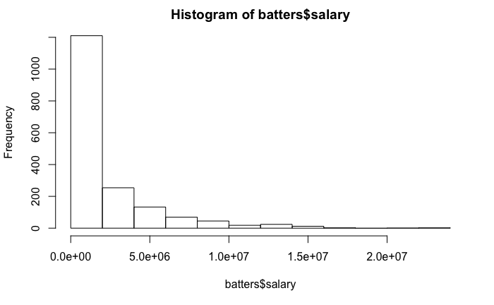

Most of the salaries are small, with a relatively small number of much larger salaries (this is referred to as ???right-skewed???).

# (f) When handling a skewed dependent variable, it is often useful to predict the logarithm of the dependent variable instead of the dependent variable itself - this prevents the small number of unusually large or small observations from having an undue influence on the predictive model. In this problem, you will predict the natural logarithm of the salary variable at the end of a season with the number of runs scored in the season and a constant (intercept). Use the entire dataset to build your model with linear regression. What does your model predict to be the logarithm of the salary of a batter who scores 0 runs in a season?

```r
model1 <- lm(log(salary) ~ R, batters)
predict1 <- predict(model1, data.frame(R = 0))
predict1
```

```
      1
13.4175
```

13.4175

# (g) What is the actual average of the logarithm of the salary of batters who score 0 runs in a season in the dataset? Remember to drop missing entries in computing this number.

```r
nalessbatters = na.omit(batters)
mean(log(nalessbatters$salary[nalessbatters$R == 0]))
```

```
[1] 13.60544
```

# (h) Comment on whether the results in questions (f) and (g) are close to each other. If yes provide a brief explanation.

Yes they are very close, just 0.2 off. This is because we have a lot of data, allowing us to create a more reliable model.